# CreditCardFraud

### Introduction

This project focuses on classifying credit card transactions as either fraudulent or non-fraudulent using machine learning algorithms. The primary objective is to develop a high-performance model capable of accurately predicting fraudulent transactions. The dataset used consists of 284,000 records, with 28 anonymized predictor variables for privacy protection. The target variable, labeled as "Class," is binary: 0 represents non-fraudulent transactions, and 1 represents fraudulent transactions.

### Results

In this analysis, we implemented several machine learning algorithms to test on our dataset. One key observation was that the dataset was severely imbalanced, with a much higher number of non-fraudulent transactions compared to fraudulent ones. This imbalance resulted in high accuracy for predicting non-fraudulent transactions but poor accuracy for detecting fraudulent ones. To address this, we tested our algorithms on two versions of the dataset: the original imbalanced dataset and a balanced dataset with roughly equal numbers of fraud and non-fraud transactions.

Before discussing the algorithms, it’s important to define the evaluation metrics used for comparison. We focused on precision, recall, and the F1-score. These metrics were chosen because they are based on the true positive rate, which is critical in fraud detection.

Precision measures the number of true positives divided by the total positive predictions. Recall measures the correct positive predictions divided by all actual positive cases. F1-score provides a balance between precision and recall. For this use case, a high true positive rate is essential to correctly identify fraudulent transactions, while minimizing the false positive rate is equally important to avoid incorrectly flagging legitimate transactions. By optimizing the balance between precision, recall, and the F1-score, we can identify the most suitable algorithm.

We tested the following algorithms: Logistic Regression, Shallow Neural Network, Random Forest Classifier, Gradient Boosting Classifier, and Linear Support Vector Classifier. These algorithms were applied to both the original imbalanced dataset and the balanced dataset.

The best-performing algorithm was the Random Forest Classifier applied to the balanced dataset. It achieved:

- Precision of 0.92 for non-fraud and 0.97 for fraud,
- Recall of 0.97 for non-fraud and 0.91 for fraud,
- F1-score of 0.95 for non-fraud and 0.94 for fraud.

```python
import pandas as pd
import numpy as np
import warnings

# Ignore only DeprecationWarnings
warnings.filterwarnings("ignore", category=DeprecationWarning)
warnings.simplefilter(action='ignore', category=FutureWarning)
```

```python
df = pd.read_csv('creditcard.csv')
```

```python
# EXPORING THE DATA
```

```python
df.head()
```

|  | Time | V1 | V2 | V3 | V4 | V5 | V6 | V7 | V8 | V9 | ... | V21 | V22 | V23 | V24 | V25 | V26 | V27 | V28 | Amount | Class |
| --- | --- | --- | --- | --- | --- | --- | --- | --- | --- | --- | --- | --- | --- | --- | --- | --- | --- | --- | --- | --- | --- |
| 0 | 0.0 | -1.359807 | -0.072781 | 2.536347 | 1.378155 | -0.338321 | 0.462388 | 0.239599 | 0.098698 | 0.363787 | ... | -0.018307 | 0.277838 | -0.110474 | 0.066928 | 0.128539 | -0.189115 | 0.133558 | -0.021053 | 149.62 | 0 |
| 1 | 0.0 | 1.191857 | 0.266151 | 0.166480 | 0.448154 | 0.060018 | -0.082361 | -0.078803 | 0.085102 | -0.255425 | ... | -0.225775 | -0.638672 | 0.101288 | -0.339846 | 0.167170 | 0.125895 | -0.008983 | 0.014724 | 2.69 | 0 |
| 2 | 1.0 | -1.358354 | -1.340163 | 1.773209 | 0.379780 | -0.503198 | 1.800499 | 0.791461 | 0.247676 | -1.514654 | ... | 0.247998 | 0.771679 | 0.909412 | -0.689281 | -0.327642 | -0.139097 | -0.055353 | -0.059752 | 378.66 | 0 |
| 3 | 1.0 | -0.966272 | -0.185226 | 1.792993 | -0.863291 | -0.010309 | 1.247203 | 0.237609 | 0.377436 | -1.387024 | ... | -0.108300 | 0.005274 | -0.190321 | -1.175575 | 0.647376 | -0.221929 | 0.062723 | 0.061458 | 123.50 | 0 |
| 4 | 2.0 | -1.158233 | 0.877737 | 1.548718 | 0.403034 | -0.407193 | 0.095921 | 0.592941 | -0.270533 | 0.817739 | ... | -0.009431 | 0.798278 | -0.137458 | 0.141267 | -0.206010 | 0.502292 | 0.219422 | 0.215153 | 69.99 | 0 |

5 rows × 31 columns

```python
df.info()
```

```
<class 'pandas.core.frame.DataFrame'>
RangeIndex: 284807 entries, 0 to 284806
Data columns (total 31 columns):
 #   Column  Non-Null Count   Dtype
---  ------  --------------   -----
 0   Time    284807 non-null  float64
 1   V1      284807 non-null  float64
 2   V2      284807 non-null  float64
 3   V3      284807 non-null  float64
 4   V4      284807 non-null  float64
 5   V5      284807 non-null  float64
 6   V6      284807 non-null  float64
 7   V7      284807 non-null  float64
 8   V8      284807 non-null  float64
 9   V9      284807 non-null  float64
```

[output cut: 23 more lines]

```python
df['Class'].unique()
df['Class'].value_counts()
```

```
Class
0    284315
1       492
Name: count, dtype: int64
```

```
array([[<Axes: title={'center': 'Time'}>, <Axes: title={'center': 'V1'}>,
        <Axes: title={'center': 'V2'}>, <Axes: title={'center': 'V3'}>,
        <Axes: title={'center': 'V4'}>, <Axes: title={'center': 'V5'}>],
       [<Axes: title={'center': 'V6'}>, <Axes: title={'center': 'V7'}>,
        <Axes: title={'center': 'V8'}>, <Axes: title={'center': 'V9'}>,
        <Axes: title={'center': 'V10'}>, <Axes: title={'center': 'V11'}>],
       [<Axes: title={'center': 'V12'}>, <Axes: title={'center': 'V13'}>,
        <Axes: title={'center': 'V14'}>, <Axes: title={'center': 'V15'}>,
        <Axes: title={'center': 'V16'}>, <Axes: title={'center': 'V17'}>],
       [<Axes: title={'center': 'V18'}>, <Axes: title={'center': 'V19'}>,
        <Axes: title={'center': 'V20'}>, <Axes: title={'center': 'V21'}>,
        <Axes: title={'center': 'V22'}>, <Axes: title={'center': 'V23'}>],
       [<Axes: title={'center': 'V24'}>, <Axes: title={'center': 'V25'}>,
        <Axes: title={'center': 'V26'}>, <Axes: title={'center': 'V27'}>,
        <Axes: title={'center': 'V28'}>,
        <Axes: title={'center': 'Amount'}>],
       [<Axes: title={'center': 'Class'}>, <Axes: >, <Axes: >, <Axes: >,
        <Axes: >, <Axes: >]], dtype=object)
```

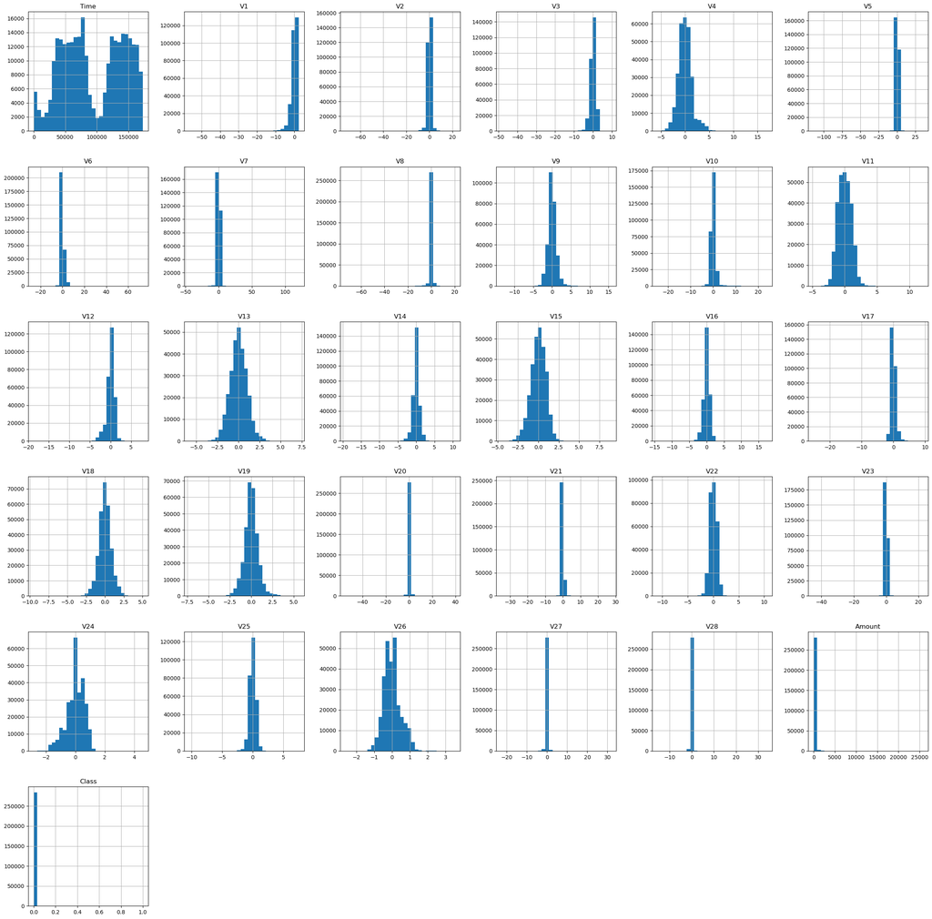

```python
df.hist(bins = 30, figsize = (30,30))
```

```python
df.describe()
```

|  | Time | V1 | V2 | V3 | V4 | V5 | V6 | V7 | V8 | V9 | ... | V21 | V22 | V23 | V24 | V25 | V26 | V27 | V28 | Amount | Class |
| --- | --- | --- | --- | --- | --- | --- | --- | --- | --- | --- | --- | --- | --- | --- | --- | --- | --- | --- | --- | --- | --- |
| count | 284807.000000 | 2.848070e+05 | 2.848070e+05 | 2.848070e+05 | 2.848070e+05 | 2.848070e+05 | 2.848070e+05 | 2.848070e+05 | 2.848070e+05 | 2.848070e+05 | ... | 2.848070e+05 | 2.848070e+05 | 2.848070e+05 | 2.848070e+05 | 2.848070e+05 | 2.848070e+05 | 2.848070e+05 | 2.848070e+05 | 284807.000000 | 284807.000000 |
| mean | 94813.859575 | 1.168375e-15 | 3.416908e-16 | -1.379537e-15 | 2.074095e-15 | 9.604066e-16 | 1.487313e-15 | -5.556467e-16 | 1.213481e-16 | -2.406331e-15 | ... | 1.654067e-16 | -3.568593e-16 | 2.578648e-16 | 4.473266e-15 | 5.340915e-16 | 1.683437e-15 | -3.660091e-16 | -1.227390e-16 | 88.349619 | 0.001727 |
| std | 47488.145955 | 1.958696e+00 | 1.651309e+00 | 1.516255e+00 | 1.415869e+00 | 1.380247e+00 | 1.332271e+00 | 1.237094e+00 | 1.194353e+00 | 1.098632e+00 | ... | 7.345240e-01 | 7.257016e-01 | 6.244603e-01 | 6.056471e-01 | 5.212781e-01 | 4.822270e-01 | 4.036325e-01 | 3.300833e-01 | 250.120109 | 0.041527 |
| min | 0.000000 | -5.640751e+01 | -7.271573e+01 | -4.832559e+01 | -5.683171e+00 | -1.137433e+02 | -2.616051e+01 | -4.355724e+01 | -7.321672e+01 | -1.343407e+01 | ... | -3.483038e+01 | -1.093314e+01 | -4.480774e+01 | -2.836627e+00 | -1.029540e+01 | -2.604551e+00 | -2.256568e+01 | -1.543008e+01 | 0.000000 | 0.000000 |
| 25% | 54201.500000 | -9.203734e-01 | -5.985499e-01 | -8.903648e-01 | -8.486401e-01 | -6.915971e-01 | -7.682956e-01 | -5.540759e-01 | -2.086297e-01 | -6.430976e-01 | ... | -2.283949e-01 | -5.423504e-01 | -1.618463e-01 | -3.545861e-01 | -3.171451e-01 | -3.269839e-01 | -7.083953e-02 | -5.295979e-02 | 5.600000 | 0.000000 |
| 50% | 84692.000000 | 1.810880e-02 | 6.548556e-02 | 1.798463e-01 | -1.984653e-02 | -5.433583e-02 | -2.741871e-01 | 4.010308e-02 | 2.235804e-02 | -5.142873e-02 | ... | -2.945017e-02 | 6.781943e-03 | -1.119293e-02 | 4.097606e-02 | 1.659350e-02 | -5.213911e-02 | 1.342146e-03 | 1.124383e-02 | 22.000000 | 0.000000 |
| 75% | 139320.500000 | 1.315642e+00 | 8.037239e-01 | 1.027196e+00 | 7.433413e-01 | 6.119264e-01 | 3.985649e-01 | 5.704361e-01 | 3.273459e-01 | 5.971390e-01 | ... | 1.863772e-01 | 5.285536e-01 | 1.476421e-01 | 4.395266e-01 | 3.507156e-01 | 2.409522e-01 | 9.104512e-02 | 7.827995e-02 | 77.165000 | 0.000000 |
| max | 172792.000000 | 2.454930e+00 | 2.205773e+01 | 9.382558e+00 | 1.687534e+01 | 3.480167e+01 | 7.330163e+01 | 1.205895e+02 | 2.000721e+01 | 1.559499e+01 | ... | 2.720284e+01 | 1.050309e+01 | 2.252841e+01 | 4.584549e+00 | 7.519589e+00 | 3.517346e+00 | 3.161220e+01 | 3.384781e+01 | 25691.160000 | 1.000000 |

8 rows × 31 columns

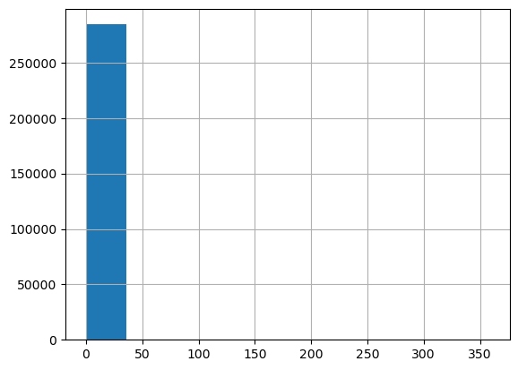

```python
from sklearn.preprocessing import RobustScaler
new_df = df.copy()
new_df['Amount'] = RobustScaler().fit_transform(new_df['Amount'].to_numpy().reshape(-1,1))
new_df['Amount'].hist()
```

```python
new_df['Amount'].describe()
```

```
count    284807.000000
mean          0.927124
std           3.495006
min          -0.307413
25%          -0.229162
50%           0.000000
75%           0.770838
max         358.683155
Name: Amount, dtype: float64
```

```python
# Scale time column to 0 to 1
time = new_df['Time']
new_df['Time'] = (time - time.min()) / (time.max() - time.min())
```

```python
new_df = new_df.sample(frac = 1, random_state = 1)
```

```python
train, test, val = new_df[:240000], new_df[240000:262000], new_df[262000:]
train['Class'].value_counts(), test['Class'].value_counts(), val['Class'].value_counts()
```

```
(Class
 0    239589
 1       411
 Name: count, dtype: int64,
 Class
 0    21955
 1       45
 Name: count, dtype: int64,
 Class
 0    22771
 1       36
 Name: count, dtype: int64)
```

```python
train_np, test_np, val_np = train.to_numpy(), test.to_numpy(), val.to_numpy()
train_np.shape, test_np.shape, val_np.shape
```

```
((240000, 31), (22000, 31), (22807, 31))
```

```python
x_train, y_train = train_np[:, :-1], train_np[:, -1]
x_test, y_test = test_np[:, :-1], test_np[:, -1]
x_val, y_val = val_np[:, :-1], val_np[:, -1]
```

```python
x_train.shape, y_train.shape, x_test.shape, y_test.shape, x_val.shape, y_val.shape
```

```
((240000, 30), (240000,), (22000, 30), (22000,), (22807, 30), (22807,))
```

After exploring our data we found no missing values. Before beginning with machine learning I also wanted to preprocess the data, so it is better suited for the algorithms. To do this I split the data set into three groups: a test group, a train group, and a validation group. I also transformed the Amount column to minimize and outliers. We will now begin testing algorithms

```python
from sklearn.linear_model import LogisticRegression
logistic_model = LogisticRegression()
logistic_model.fit(x_train, y_train)
logistic_model.score(x_train, y_train)
```

```
0.9992375
```

```python
from sklearn.metrics import classification_report
print(classification_report(y_val, logistic_model.predict(x_val), target_names = ['Not Fraud', 'Fraud']))
```

```
              precision    recall  f1-score   support

   Not Fraud       1.00      1.00      1.00     22771
       Fraud       0.73      0.53      0.61        36

    accuracy                           1.00     22807
   macro avg       0.87      0.76      0.81     22807
weighted avg       1.00      1.00      1.00     22807
```

```python
# Since there are so many not frauds it is easy to predict not fraud and harder to find the frauds. This means we have an imbalanced dataset
## recall is false negatives (want high recall so fraud is caught)
```

```python
from tensorflow.keras.models import Sequential
from tensorflow.keras.layers import InputLayer, Dense, BatchNormalization
from tensorflow.keras.callbacks import ModelCheckpoint

shallow_nn = Sequential()
shallow_nn.add(InputLayer((x_train.shape[1],)))
shallow_nn.add(Dense(2, 'relu'))
shallow_nn.add(BatchNormalization())
shallow_nn.add(Dense(1, 'sigmoid'))

checkpoint = ModelCheckpoint('shallow_nn.keras', save_best_only = True)
shallow_nn.compile(optimizer='adam', loss='binary_crossentropy', metrics=['accuracy'])
```

```python
shallow_nn.summary()
```

```
Model: "sequential_1"
```

```
┏━━━━━━━━━━━━━━━━━━━━━━━━━━━━━━━━━┳━━━━━━━━━━━━━━━━━━━━━━━━┳━━━━━━━━━━━━━━━┓
┃ Layer (type)                    ┃ Output Shape           ┃       Param # ┃
┡━━━━━━━━━━━━━━━━━━━━━━━━━━━━━━━━━╇━━━━━━━━━━━━━━━━━━━━━━━━╇━━━━━━━━━━━━━━━┩
│ dense_2 (Dense)                 │ (None, 2)              │            62 │
├─────────────────────────────────┼────────────────────────┼───────────────┤
│ batch_normalization_1           │ (None, 2)              │             8 │
│ (BatchNormalization)            │                        │               │
├─────────────────────────────────┼────────────────────────┼───────────────┤
│ dense_3 (Dense)                 │ (None, 1)              │             3 │
└─────────────────────────────────┴────────────────────────┴───────────────┘
```

```
 Total params: 73 (292.00 B)
```

```
 Trainable params: 69 (276.00 B)
```

```
 Non-trainable params: 4 (16.00 B)
```

```python
shallow_nn.fit(x_train, y_train, validation_data=(x_val, y_val), epochs = 5, callbacks = checkpoint)
```

```
7500/7500 ━━━━━━━━━━━━━━━━━━━━ 2s 251us/step - accuracy: 0.9520 - loss: 0.1630 - val_accuracy: 0.9990 - val_loss: 0.0091
7500/7500 ━━━━━━━━━━━━━━━━━━━━ 2s 235us/step - accuracy: 0.9994 - loss: 0.0034 - val_accuracy: 0.9986 - val_loss: 0.0137
7500/7500 ━━━━━━━━━━━━━━━━━━━━ 2s 238us/step - accuracy: 0.9993 - loss: 0.0034 - val_accuracy: 0.9991 - val_loss: 0.0102
7500/7500 ━━━━━━━━━━━━━━━━━━━━ 2s 239us/step - accuracy: 0.9994 - loss: 0.0032 - val_accuracy: 0.9989 - val_loss: 0.0106
7500/7500 ━━━━━━━━━━━━━━━━━━━━ 2s 240us/step - accuracy: 0.9994 - loss: 0.0029 - val_accuracy: 0.9990 - val_loss: 0.0094
```

```
<keras.src.callbacks.history.History at 0x327eca390>
```

```python
def neural_net_predictions(model, x):
    return (shallow_nn.predict(x).flatten() > 0.5).astype(int)

neural_net_predictions(shallow_nn, x_val)
```

```
713/713 ━━━━━━━━━━━━━━━━━━━━ 0s 202us/step
```

```
array([0, 0, 0, ..., 0, 0, 0])
```

```python
print(classification_report(y_val, neural_net_predictions(shallow_nn, x_val), target_names=['Not Fraud', 'Fraud']))
```

```
713/713 ━━━━━━━━━━━━━━━━━━━━ 0s 187us/step
              precision    recall  f1-score   support

   Not Fraud       1.00      1.00      1.00     22771
       Fraud       0.68      0.75      0.71        36

    accuracy                           1.00     22807
   macro avg       0.84      0.87      0.86     22807
weighted avg       1.00      1.00      1.00     22807
```

```python
from sklearn.ensemble import RandomForestClassifier
rf = RandomForestClassifier(max_depth=2, n_jobs = -1)
rf.fit(x_train, y_train)
print(classification_report(y_val, rf.predict(x_val), target_names=['Not Fraud', 'Fraud']))
```

```
              precision    recall  f1-score   support

   Not Fraud       1.00      1.00      1.00     22771
       Fraud       0.81      0.47      0.60        36

    accuracy                           1.00     22807
   macro avg       0.90      0.74      0.80     22807
weighted avg       1.00      1.00      1.00     22807
```

```python
from sklearn.ensemble import GradientBoostingClassifier
gbc = GradientBoostingClassifier(n_estimators = 50, learning_rate= 1.0, max_depth=1, random_state = 0)
gbc.fit(x_train, y_train)
print(classification_report(y_val, gbc.predict(x_val), target_names=['Not Fraud', 'Fraud']))
```

```
              precision    recall  f1-score   support

   Not Fraud       1.00      1.00      1.00     22771
       Fraud       0.67      0.67      0.67        36

    accuracy                           1.00     22807
   macro avg       0.83      0.83      0.83     22807
weighted avg       1.00      1.00      1.00     22807
```

```python
from sklearn.svm import LinearSVC
svc = LinearSVC(class_weight = 'balanced')
svc.fit(x_train, y_train)
print(classification_report(y_val, svc.predict(x_val), target_names=['Not Fraud', 'Fraud']))
```

```
              precision    recall  f1-score   support

   Not Fraud       1.00      1.00      1.00     22771
       Fraud       0.61      0.75      0.67        36

    accuracy                           1.00     22807
   macro avg       0.81      0.87      0.84     22807
weighted avg       1.00      1.00      1.00     22807
```

```python
frauds = new_df.query('Class == 1')
not_frauds = new_df.query('Class == 0')
not_frauds['Class'].value_counts(), frauds['Class'].value_counts()
```

```
(Class
 0    284315
 Name: count, dtype: int64,
 Class
 1    492
 Name: count, dtype: int64)
```

```python
balanced_df = pd.concat([frauds, not_frauds.sample(len(frauds), random_state = 1)])
balanced_df['Class'].value_counts()
```

```
Class
1    492
0    492
Name: count, dtype: int64
```

```python
balanced_df = balanced_df.sample(frac = 1, random_state = 1)
balanced_df
```

|  | Time | V1 | V2 | V3 | V4 | V5 | V6 | V7 | V8 | V9 | ... | V21 | V22 | V23 | V24 | V25 | V26 | V27 | V28 | Amount | Class |
| --- | --- | --- | --- | --- | --- | --- | --- | --- | --- | --- | --- | --- | --- | --- | --- | --- | --- | --- | --- | --- | --- |
| 18372 | 0.170309 | -1.762593 | 0.256143 | 1.683125 | -1.279233 | -1.902762 | 1.004210 | -1.009748 | -2.432546 | 0.458860 | ... | 2.493579 | 0.320829 | -0.535481 | 0.499401 | -0.915196 | -0.423434 | 0.107049 | 0.175922 | 2.906449 | 0 |
| 96341 | 0.380388 | 1.227614 | -0.668974 | -0.271785 | -0.589440 | -0.604795 | -0.350285 | -0.486365 | -0.010809 | -0.794944 | ... | -0.026055 | -0.295255 | -0.180459 | -0.436539 | 0.494649 | -0.283738 | -0.001128 | 0.035075 | 1.062111 | 1 |
| 248296 | 0.890522 | -0.613696 | 3.698772 | -5.534941 | 5.620486 | 1.649263 | -2.335145 | -0.907188 | 0.706362 | -3.747646 | ... | 0.319261 | -0.471379 | -0.075890 | -0.667909 | -0.642848 | 0.070600 | 0.488410 | 0.292345 | -0.307413 | 1 |
| 264328 | 0.933932 | -0.011624 | 0.640413 | 0.868046 | -0.505279 | 0.261938 | 0.223098 | 0.239049 | 0.150877 | 0.225142 | ... | 0.069401 | 0.268024 | 0.261459 | 0.683742 | -1.567901 | -0.816674 | 0.185781 | 0.283021 | -0.272619 | 0 |
| 208904 | 0.794730 | -0.679341 | 1.217389 | -0.316778 | -1.086725 | 0.855349 | -0.980760 | 0.970589 | 0.133116 | -0.357671 | ... | -0.083048 | -0.137032 | -0.238920 | -0.617244 | 0.039020 | -0.081848 | 0.234633 | 0.128382 | -0.307273 | 0 |
| ... | ... | ... | ... | ... | ... | ... | ... | ... | ... | ... | ... | ... | ... | ... | ... | ... | ... | ... | ... | ... | ... |
| 81557 | 0.341393 | -4.502731 | -3.876484 | 1.341248 | 0.113400 | 0.189428 | -0.560985 | -0.140478 | 0.684651 | 0.475363 | ... | -0.140218 | 0.049411 | 2.313731 | 0.252330 | 0.307219 | 0.859051 | 0.184033 | -0.308269 | 4.227625 | 0 |
| 276071 | 0.965803 | 2.091900 | -0.757459 | -1.192258 | -0.755458 | -0.620324 | -0.322077 | -1.082511 | 0.117200 | -0.140927 | ... | 0.288253 | 0.831939 | 0.142007 | 0.592615 | -0.196143 | -0.136676 | 0.020182 | -0.015470 | -0.028645 | 1 |
| 175971 | 0.709373 | 1.972989 | 0.157281 | -1.715078 | 1.207451 | 0.681612 | -0.615282 | 0.601791 | -0.291935 | -0.132265 | ... | 0.098640 | 0.467533 | -0.078973 | -0.371882 | 0.486038 | -0.490665 | -0.018374 | -0.070911 | 0.075735 | 0 |
| 27738 | 0.200727 | -2.439237 | 2.591458 | -2.840126 | 1.286244 | -1.777016 | -1.436139 | -2.206056 | -2.282725 | -0.292885 | ... | 1.774460 | -0.771390 | 0.065727 | 0.103916 | -0.057578 | 0.242652 | -0.268649 | -0.743713 | 1.443443 | 1 |
| 156988 | 0.632535 | 0.745153 | 2.809299 | -5.825406 | 5.835566 | 0.512320 | -0.615622 | -2.916576 | 0.776710 | -1.878832 | ... | 0.284841 | -0.874383 | -0.083995 | -0.651442 | 0.454594 | 0.050376 | 0.756953 | 0.383869 | -0.307413 | 1 |

984 rows × 31 columns

```python
balanced_df_np = balanced_df.to_numpy()
```

```python
x_train_b, y_train_b = balanced_df_np[: 700, :-1], balanced_df_np[: 700, -1].astype(int)
x_test_b, y_test_b = balanced_df_np[700:842, :-1], balanced_df_np[700:842, -1].astype(int)
x_val_b, y_val_b = balanced_df_np[842:, :-1], balanced_df_np[842:, -1].astype(int)
x_train_b.shape, y_train_b.shape, x_test_b.shape, y_test_b. shape, x_val_b.shape, y_val_b.shape
```

```
((700, 30), (700,), (142, 30), (142,), (142, 30), (142,))
```

```python
pd.Series(y_train_b).value_counts(),pd.Series(y_test_b).value_counts(), pd.Series(y_val_b).value_counts()
```

```
(1    353
 0    347
 Name: count, dtype: int64,
 0    73
 1    69
 Name: count, dtype: int64,
 0    72
 1    70
 Name: count, dtype: int64)
```

```python
logistic_model_b = LogisticRegression()
logistic_model_b.fit(x_train_b, y_train_b)
print(classification_report(y_val_b, logistic_model_b.predict(x_val_b), target_names=['Not Fraud', 'Fraud']))
```

```
              precision    recall  f1-score   support

   Not Fraud       0.96      0.93      0.94        72
       Fraud       0.93      0.96      0.94        70

    accuracy                           0.94       142
   macro avg       0.94      0.94      0.94       142
weighted avg       0.94      0.94      0.94       142
```

```python
shallow_nn_b = Sequential()
shallow_nn_b.add(InputLayer((x_train_b.shape[1],)))
shallow_nn_b.add(Dense(2, 'relu'))
shallow_nn_b.add(BatchNormalization())
shallow_nn_b.add(Dense(1, 'sigmoid'))

checkpoint = ModelCheckpoint('shallow_nn_b.keras', save_best_only = True)
shallow_nn_b.compile(optimizer = 'adam', loss = 'binary_crossentropy', metrics = ['accuracy'])
shallow_nn_b.fit(x_train_b, y_train_b, validation_data = (x_val_b, y_val_b), epochs = 40, callbacks = checkpoint)
```

```
22/22 ━━━━━━━━━━━━━━━━━━━━ 0s 4ms/step - accuracy: 0.6444 - loss: 0.6500 - val_accuracy: 0.6761 - val_loss: 0.6759
22/22 ━━━━━━━━━━━━━━━━━━━━ 0s 903us/step - accuracy: 0.6593 - loss: 0.6379 - val_accuracy: 0.7113 - val_loss: 0.6525
22/22 ━━━━━━━━━━━━━━━━━━━━ 0s 1ms/step - accuracy: 0.6631 - loss: 0.6329 - val_accuracy: 0.6972 - val_loss: 0.6388
22/22 ━━━━━━━━━━━━━━━━━━━━ 0s 980us/step - accuracy: 0.6578 - loss: 0.6284 - val_accuracy: 0.6901 - val_loss: 0.6292
22/22 ━━━━━━━━━━━━━━━━━━━━ 0s 1ms/step - accuracy: 0.6789 - loss: 0.6051 - val_accuracy: 0.6831 - val_loss: 0.6222
22/22 ━━━━━━━━━━━━━━━━━━━━ 0s 1ms/step - accuracy: 0.7096 - loss: 0.5935 - val_accuracy: 0.6901 - val_loss: 0.6162
22/22 ━━━━━━━━━━━━━━━━━━━━ 0s 925us/step - accuracy: 0.6953 - loss: 0.5757 - val_accuracy: 0.6901 - val_loss: 0.6103
22/22 ━━━━━━━━━━━━━━━━━━━━ 0s 935us/step - accuracy: 0.7249 - loss: 0.5661 - val_accuracy: 0.6972 - val_loss: 0.6047
22/22 ━━━━━━━━━━━━━━━━━━━━ 0s 931us/step - accuracy: 0.7229 - loss: 0.5616 - val_accuracy: 0.6972 - val_loss: 0.5998
22/22 ━━━━━━━━━━━━━━━━━━━━ 0s 1ms/step - accuracy: 0.7231 - loss: 0.5675 - val_accuracy: 0.6972 - val_loss: 0.5941
22/22 ━━━━━━━━━━━━━━━━━━━━ 0s 950us/step - accuracy: 0.7247 - loss: 0.5650 - val_accuracy: 0.6972 - val_loss: 0.5888
22/22 ━━━━━━━━━━━━━━━━━━━━ 0s 965us/step - accuracy: 0.7556 - loss: 0.5316 - val_accuracy: 0.7113 - val_loss: 0.5833
22/22 ━━━━━━━━━━━━━━━━━━━━ 0s 1ms/step - accuracy: 0.7369 - loss: 0.5530 - val_accuracy: 0.7113 - val_loss: 0.5774
22/22 ━━━━━━━━━━━━━━━━━━━━ 0s 943us/step - accuracy: 0.7288 - loss: 0.5431 - val_accuracy: 0.7324 - val_loss: 0.5708
22/22 ━━━━━━━━━━━━━━━━━━━━ 0s 960us/step - accuracy: 0.7647 - loss: 0.5218 - val_accuracy: 0.7324 - val_loss: 0.5626
22/22 ━━━━━━━━━━━━━━━━━━━━ 0s 981us/step - accuracy: 0.7587 - loss: 0.5190 - val_accuracy: 0.7535 - val_loss: 0.5544
22/22 ━━━━━━━━━━━━━━━━━━━━ 0s 1ms/step - accuracy: 0.7860 - loss: 0.4966 - val_accuracy: 0.7746 - val_loss: 0.5440
22/22 ━━━━━━━━━━━━━━━━━━━━ 0s 977us/step - accuracy: 0.7678 - loss: 0.5041 - val_accuracy: 0.7887 - val_loss: 0.5315
22/22 ━━━━━━━━━━━━━━━━━━━━ 0s 984us/step - accuracy: 0.7674 - loss: 0.5070 - val_accuracy: 0.7958 - val_loss: 0.5164
22/22 ━━━━━━━━━━━━━━━━━━━━ 0s 897us/step - accuracy: 0.7885 - loss: 0.4723 - val_accuracy: 0.8169 - val_loss: 0.4967
22/22 ━━━━━━━━━━━━━━━━━━━━ 0s 951us/step - accuracy: 0.8196 - loss: 0.4658 - val_accuracy: 0.8380 - val_loss: 0.4769
22/22 ━━━━━━━━━━━━━━━━━━━━ 0s 981us/step - accuracy: 0.8121 - loss: 0.4441 - val_accuracy: 0.8592 - val_loss: 0.4602
22/22 ━━━━━━━━━━━━━━━━━━━━ 0s 933us/step - accuracy: 0.8537 - loss: 0.4134 - val_accuracy: 0.8662 - val_loss: 0.4428
22/22 ━━━━━━━━━━━━━━━━━━━━ 0s 1ms/step - accuracy: 0.8717 - loss: 0.4031 - val_accuracy: 0.8662 - val_loss: 0.4261
22/22 ━━━━━━━━━━━━━━━━━━━━ 0s 1ms/step - accuracy: 0.8429 - loss: 0.4082 - val_accuracy: 0.8873 - val_loss: 0.4083
22/22 ━━━━━━━━━━━━━━━━━━━━ 0s 1ms/step - accuracy: 0.8346 - loss: 0.4025 - val_accuracy: 0.8944 - val_loss: 0.3902
22/22 ━━━━━━━━━━━━━━━━━━━━ 0s 1ms/step - accuracy: 0.8975 - loss: 0.3377 - val_accuracy: 0.9014 - val_loss: 0.3737
22/22 ━━━━━━━━━━━━━━━━━━━━ 0s 990us/step - accuracy: 0.8905 - loss: 0.3215 - val_accuracy: 0.9085 - val_loss: 0.3580
22/22 ━━━━━━━━━━━━━━━━━━━━ 0s 2ms/step - accuracy: 0.8832 - loss: 0.3186 - val_accuracy: 0.9225 - val_loss: 0.3416
22/22 ━━━━━━━━━━━━━━━━━━━━ 0s 2ms/step - accuracy: 0.9044 - loss: 0.3056 - val_accuracy: 0.9296 - val_loss: 0.3264
22/22 ━━━━━━━━━━━━━━━━━━━━ 0s 1ms/step - accuracy: 0.8893 - loss: 0.3046 - val_accuracy: 0.9296 - val_loss: 0.3134
22/22 ━━━━━━━━━━━━━━━━━━━━ 0s 1ms/step - accuracy: 0.9134 - loss: 0.2746 - val_accuracy: 0.9225 - val_loss: 0.3002
22/22 ━━━━━━━━━━━━━━━━━━━━ 0s 1ms/step - accuracy: 0.9158 - loss: 0.2619 - val_accuracy: 0.9225 - val_loss: 0.2881
22/22 ━━━━━━━━━━━━━━━━━━━━ 0s 1ms/step - accuracy: 0.9179 - loss: 0.2497 - val_accuracy: 0.9225 - val_loss: 0.2788
22/22 ━━━━━━━━━━━━━━━━━━━━ 0s 979us/step - accuracy: 0.9219 - loss: 0.2367 - val_accuracy: 0.9225 - val_loss: 0.2703
22/22 ━━━━━━━━━━━━━━━━━━━━ 0s 1ms/step - accuracy: 0.9352 - loss: 0.2281 - val_accuracy: 0.9225 - val_loss: 0.2623
22/22 ━━━━━━━━━━━━━━━━━━━━ 0s 963us/step - accuracy: 0.9381 - loss: 0.2167 - val_accuracy: 0.9225 - val_loss: 0.2531
22/22 ━━━━━━━━━━━━━━━━━━━━ 0s 1ms/step - accuracy: 0.9350 - loss: 0.2203 - val_accuracy: 0.9225 - val_loss: 0.2457
22/22 ━━━━━━━━━━━━━━━━━━━━ 0s 1ms/step - accuracy: 0.9415 - loss: 0.2180 - val_accuracy: 0.9225 - val_loss: 0.2398
22/22 ━━━━━━━━━━━━━━━━━━━━ 0s 1ms/step - accuracy: 0.9551 - loss: 0.1935 - val_accuracy: 0.9225 - val_loss: 0.2321
```

```
<keras.src.callbacks.history.History at 0x1613ed2d0>
```

```python
# overfitting acurracy is much higher than val_accuracy
```

```python
print(classification_report(y_val_b, neural_net_predictions(shallow_nn_b, x_val_b), target_names=['Not Fraud', 'Fraud']))
```

```
5/5 ━━━━━━━━━━━━━━━━━━━━ 0s 575us/step
              precision    recall  f1-score   support

   Not Fraud       0.89      1.00      0.94        72
       Fraud       1.00      0.87      0.93        70

    accuracy                           0.94       142
   macro avg       0.94      0.94      0.94       142
weighted avg       0.94      0.94      0.94       142
```

```python
rf_b = RandomForestClassifier(max_depth=2, n_jobs = -1)
rf_b.fit(x_train_b, y_train_b)
print(classification_report(y_val_b, rf_b.predict(x_val_b), target_names=['Not Fraud', 'Fraud']))
```

```
              precision    recall  f1-score   support

   Not Fraud       0.92      0.97      0.95        72
       Fraud       0.97      0.91      0.94        70

    accuracy                           0.94       142
   macro avg       0.95      0.94      0.94       142
weighted avg       0.95      0.94      0.94       142
```

```python
gbc_b = GradientBoostingClassifier(n_estimators = 100, learning_rate= 1.0, max_depth=2, random_state = 0)
gbc_b.fit(x_train_b, y_train_b)
print(classification_report(y_val_b, gbc.predict(x_val_b), target_names=['Not Fraud', 'Fraud']))
```

```
              precision    recall  f1-score   support

   Not Fraud       0.94      0.92      0.93        72
       Fraud       0.92      0.94      0.93        70

    accuracy                           0.93       142
   macro avg       0.93      0.93      0.93       142
weighted avg       0.93      0.93      0.93       142
```

```python
svc_b = LinearSVC(class_weight = 'balanced')
svc_b.fit(x_train_b, y_train_b)
print(classification_report(y_val_b, svc.predict(x_val_b), target_names=['Not Fraud', 'Fraud']))
```

```
              precision    recall  f1-score   support

   Not Fraud       0.88      1.00      0.94        72
       Fraud       1.00      0.86      0.92        70

    accuracy                           0.93       142
   macro avg       0.94      0.93      0.93       142
weighted avg       0.94      0.93      0.93       142
```

```python
print(classification_report(y_test_b, neural_net_predictions(shallow_nn, x_test_b), target_names = ['Not Fraud', 'Fraud']))
```

```
5/5 ━━━━━━━━━━━━━━━━━━━━ 0s 504us/step
              precision    recall  f1-score   support

   Not Fraud       0.86      1.00      0.92        73
       Fraud       1.00      0.83      0.90        69

    accuracy                           0.92       142
   macro avg       0.93      0.91      0.91       142
weighted avg       0.93      0.92      0.91       142
```